# Controlling for Confounders

The Frisch-Waugh-Lovell Theorem

Tom Hackenberg · Block 2

2025-04-14

# Controlling for Confounders

### The Frisch-Waugh-Lovell Theorem

*What does “controlling for X” actually mean?*

`Causal Inference · MSc · Week 11 of 15 · 120 min`

## Roadmap — the lecture

| Part | Topic | Time |
| --- | --- | --- |
| **1 — Geometry** | What regression does in space | ~25 min |
| **2 — Theorem** | FWL: proof + numerical verification | ~20 min |
| **3 — Failure modes** | When OLS FWL breaks | ~20 min |
| **4 — Double ML** | Replace OLS with ML | ~20 min |
| **5 — Neyman** | Why the “double” matters | ~10 min |
| **Checkpoints** | Three exam-style questions | woven in |

## Roadmap — your payoff

**Three audiences, three payoffs:**

🎓 **Social science** — what “controlling for” *means* conceptually, not just how to do it. Parts 1–2 are your core.

💻 **CS / ML** — the algorithm and precisely where it breaks. Parts 3–4 and the cross-fitting diagram.

📈 **Econ / management** — when to trust an estimate and when to be suspicious. Parts 2–3 and the comparison table.

**Note**

The thread across weeks: **FWL** → **Double ML** → **CATE** (Weeks 11–12–15). Today is the algebraic engine. Everything from here builds on this.

# Part 1 · Geometry

*Before any formula — what is regression actually doing?*

## The number that should make you nervous

You run OLS of sales on ad spend: $\hat\beta = 3.2$

£1,000 more in ad spend → £3,200 more sales.

**The problem:** firms with better products advertise more *and* sell more. Quality drives both — it confounds the comparison.

**Important**

**The question for today:** when you add quality as a control, what does OLS *actually do* — and why does that fix the bias?

Think of $Y$, $T$, $X$ as **vectors in $\mathbb{R}^n$** — one coordinate per observation. Regression is **projection**.

**Tip**

**T̃ is not “T with X removed.”** It is the variation in T that X **cannot predict**. T̃ is orthogonal to col(X) by construction — that is what residualising does.

Do the same for $Y$. Both residuals $\tilde T$ and $\tilde Y$ land in the space $X$ knows nothing about.

[figure not shown]

We have not written a single formula yet — and we already know what $\hat\beta$ is.

$\hat\beta$ is the slope between $\tilde Y$ and $\tilde T$: both stripped of everything $X$ can linearly explain.

**“Controlling for $X$” means working in the space orthogonal to $X$.**

The formula is just the algebraic statement of the picture we just drew.

**Note**

Every coefficient in every multivariate OLS you have ever run is already a partialling-out estimator. FWL proves it — and in doing so tells you exactly when the approach works and exactly when it fails.

# Part 2 · The Theorem

*Formalise what the geometry already showed*

## The Frisch-Waugh-Lovell Theorem

**Theorem (FWL, 1933–1963)**

The OLS coefficient $\hat\beta$ on $T$ in the full regression $Y = \alpha + \beta T + \gamma' X + \varepsilon$ is *numerically identical* to the coefficient from:

| Step | Operation | Result |
| --- | --- | --- |
| **1** | Regress $T$ on $X$ → save residuals | $\tilde T$ — variation in T unexplained by X |
| **2** | Regress $Y$ on $X$ → save residuals | $\tilde Y$ — variation in Y unexplained by X |
| **3** | Regress $\tilde Y$ on $\tilde T$ (no intercept) | $\hat\beta$ — *identical to the full regression* |

Steps 1 and 2 can be done in either order.

**Warning**

**Both sides must be residualised.**

Regressing raw $Y$ on $\tilde T$ — skipping Step 2 — gives a *different* estimator.

Nothing in the regression output flags this mistake. This is the most common FWL implementation error. The diagnostic: if your FWL coefficient disagrees with the full OLS, check whether you residualised both sides.

```python
T_s = pd.Series(T, name="T");  W_s = pd.Series(W, name="W")

# Step 1 — residualise T on W
T_tilde = sm.OLS(T_s, sm.add_constant(W_s)).fit().resid

# Step 2 — residualise Y on W
Y_tilde = sm.OLS(Y, sm.add_constant(W_s)).fit().resid

# Step 3 — regress Ỹ on T̃
beta_fwl  = sm.OLS(Y_tilde, T_tilde).fit().params.iloc[0]
beta_full = sm.OLS(Y, sm.add_constant(data[["T", "W"]])).fit().params["T"]

print(f"Full OLS β̂  = {beta_full:.10f}")
print(f"FWL Step 3  = {beta_fwl:.10f}")
print(f"Difference  = {abs(beta_full - beta_fwl):.2e}")
```

```
Full OLS β̂  = 1.5011541198
FWL Step 3  = 1.5011541198
Difference  = 2.22e-16
```

*Post-lecture notebook: reproduce all three steps, then plot $\tilde Y$ against $\tilde T$.*

## Proof sketch — the annihilator matrix

> *Optional — follow the algebra or trust the picture*

Define $M_X = I - X(X'X)^{-1}X'$. Three properties:

| Property | Statement | Meaning |
| --- | --- | --- |
| **Idempotent** | $M_X^2 = M_X$ | Projecting twice = projecting once |
| **Annihilates $X$** | $M_X X = 0$ | Any vector in col($X$) maps to zero |
| **Projects to col$(X)^\perp$** | $M_X v \perp X$ for any $v$ | Output is always orthogonal to $X$ |

Note $M_X T = \tilde T$ and $M_X Y = \tilde Y$ — precisely the FWL residuals. Therefore:

$$\hat\beta_{\text{OLS}} = (T' M_X T)^{-1} T' M_X Y = (\tilde T' \tilde T)^{-1} \tilde T' \tilde Y = \hat\beta_{\text{FWL}} \qquad \square$$

## ✎ Checkpoint 1 — the question

**Part A — explain**

In words: why does Step 3 of FWL give *exactly* the same coefficient as full OLS? What is it about $\tilde T$ that makes the equivalence hold?

**Part B — diagnose**

A colleague runs the three FWL steps and gets $\hat\beta = 1.7$. The full OLS gives $\hat\beta = 1.5$. Assuming no arithmetic errors — what went wrong?

*Hint: what is $\tilde T$ orthogonal to? What does that mean for adding $X$ to Step 3?*

## Checkpoint 1 — Part A

**Why does Step 3 give exactly the same number as the full regression?**

$\tilde T$ is orthogonal to col($X$) by construction — that is literally what residualising does.

Adding $X$ as a regressor in Step 3 would change nothing: $X$ has no additional explanatory power for anything already orthogonal to it.

The full regression and FWL Step 3 are solving the same optimisation in the same space. Exact equality follows — not approximately, to machine precision.

**Note**

The geometry says the same thing: $\tilde T$ lives in the orthogonal complement of col($X$). Regressing in that space is equivalent to the full regression restricted to that space.

## Checkpoint 1 — Part B

**What procedural error produces $\hat\beta = 1.7$ instead of $1.5$?**

The colleague residualised $T$ (Step 1) correctly, but regressed **raw $Y$** on $\tilde T$ instead of $\tilde Y$ on $\tilde T$.

**Rule: both variables must be residualised. Skipping either side breaks the equivalence.**

**Note**

**Exam signal:** diagnosing a FWL / full OLS mismatch is a fair exam question. The answer always traces back to one of the two residuals being wrong or missing.

# Part 3 · When It Breaks

*FWL is exact — but only if you partial out the right things, correctly*

## Failure mode 1 — the collider trap

FWL tells you *how* to partial out. Not *what* to partial out. That is a DAG question.

[figure not shown]

**Draw your DAG before running anything.** FWL on the wrong adjustment set gives an exact answer to the wrong question.

## Failure mode 2 — non-linear confounders

OLS residualisation removes only the **linear** part of $X$’s influence on $T$.

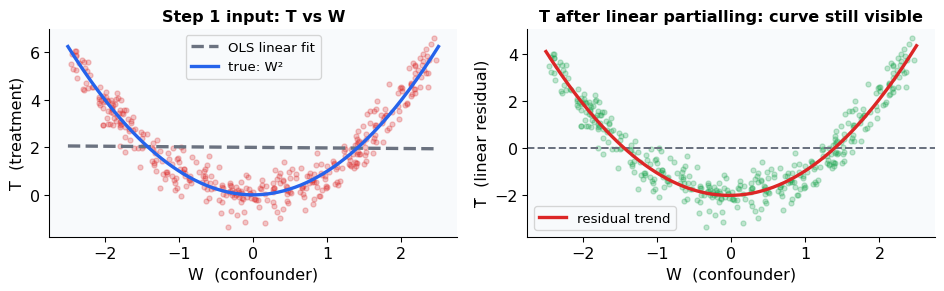

**T̃ is free of the *linear* effect of X — not free of X.**

That is a strictly weaker guarantee.

If residuals show structure when plotted against a control, partialling is incomplete — and $\hat\beta$ is biased. The regression output gives no warning.

**Warning**

This is the gap that Double ML closes. A flexible ML model in Steps 1 & 2 fits the true curve — not just a straight line. The residuals it produces are genuinely orthogonal to $X$, not just linearly orthogonal.

## Failure mode 3 — high dimensions

| Regime | What breaks |
| --- | --- |
| $p > n$ | $(X'X)$ is singular — OLS cannot be computed |
| $p$ close to $n$ | OLS overfits Steps 1 & 2 — residuals are noise |
| Non-linear confounders | Residuals still contain confounding |
| Many correlated controls | $\tilde T$ has near-zero variance → huge SE on $\hat\beta$ |

The right question is not “can I include more controls?” **The right question is: can I partial out $X$ from $T$ and $Y$ correctly at this scale?**

OLS says no beyond a certain point. But the *structure* of FWL still holds — we just need a more flexible tool for the partialling steps. That is what Double ML provides.

## ✎ Checkpoint 2 — the question

A public health researcher estimates the effect of air pollution ($T$) on hospital admissions ($Y$), controlling **linearly** for income ($X$).

Income has a strongly **concave** effect on both pollution exposure and health outcomes.

They report $\hat\beta = 0.8$ with a tight confidence interval.

**Should you trust this? What exactly goes wrong — and is the bias visible in the output?**

*Hint: what does OLS partialling remove from $T$? What does it leave behind?*

## Checkpoint 2 — answer

**No. Linear partialling removes only the linear component of income’s influence.**

The concave (non-linear) part remains inside $\tilde T$ — so $\tilde T$ is not truly free of income.

**The bias chain:**

1. OLS fits a straight line through (income, pollution) in Step 1
2. The concave residual stays in $\tilde T$ — high pollution at very low *and* very high incomes
3. That residual correlates with hospital admissions through income’s non-linear health effect
4. Step 3 attributes that correlation to pollution

**Is the bias visible in the output?** No. Small standard errors and a significant p-value confirm statistical power, not correct identification. The diagnostic is to plot $\tilde T$ against income: a visible curve means partialling is incomplete.

# Part 4 · Double Machine Learning

*Replace OLS in Steps 1 & 2 — the fix is almost embarrassingly simple*

## The simple insight

FWL says: partial out $X$ from $T$ and $Y$, then regress residuals.

**It does not say to use OLS for the partialling.**

Replace Steps 1 & 2 with any flexible ML learner:

| Step | What we fit | Residual |
| --- | --- | --- |
| **1a** | $\hat g(X) = \mathbb{E}[Y \mid X]$ via ML | $\tilde Y = Y - \hat g(X)$ |
| **1b** | $\hat m(X) = \mathbb{E}[T \mid X]$ via ML | $\tilde T = T - \hat m(X)$ |
| **2** | OLS of $\tilde Y$ on $\tilde T$ | $\hat\theta$ — causal effect |

Any learner works: LASSO, Random Forest, Gradient Boosting, Neural Net.

The FWL algebra is unchanged. ML does the heavy lifting in Steps 1 & 2.

## Why naïve swap fails

Plugging ML directly into Steps 1 & 2 without care introduces two new problems:

**Problem 1 — Regularisation**

ML shrinks predictions toward the mean. Residuals are systematically too large. The signal in $\tilde T$ is distorted.

**Problem 2 — Overfitting contamination**

ML trained and evaluated on the *same* data memorises noise. In-sample residuals are too small — they under-represent true unexplained variation.

Both problems corrupt $\tilde T$ and $\tilde Y$ before Step 2 runs.

**Cross-fitting fixes both.**

## Cross-fitting — the idea

**The problem:** ML memorises training data. In-sample residuals are contaminated.

**The solution:** for each observation, generate its residual from a model that *never saw it*.

This is K-fold cross-validation — but instead of evaluating prediction accuracy, you are generating **honest residuals** for the causal OLS.

**Tip**

Each fold’s residuals come from a model trained on all *other* folds. No overfitting contamination. The residuals are honest — as if you had infinite separate datasets.

K = 5 is standard: 80% training data per round, stable across runs.

## Cross-fitting — the procedure

[figure not shown]

## DML — the algorithm

```python
from sklearn.ensemble import RandomForestRegressor
from sklearn.model_selection import KFold

kf      = KFold(n_splits=5, shuffle=True, random_state=42)
T_tilde = np.zeros(n)
Y_tilde = np.zeros(n)

for train_idx, val_idx in kf.split(X):
    for target, store in [(T, T_tilde), (Y, Y_tilde)]:
        rf = RandomForestRegressor(n_estimators=200, random_state=42)
        rf.fit(X[train_idx], target[train_idx])
        store[val_idx] = target[val_idx] - rf.predict(X[val_idx])

# Pure FWL on honest residuals
theta_dml = np.dot(T_tilde, Y_tilde) / np.dot(T_tilde, T_tilde)
```

**Note**

**Post-lecture notebook:** you implement this from scratch — same DGP, five-fold cross-fitting, and a four-estimator comparison figure reused in the Week 12 deck.

## DML — when to use what

| Estimator | Non-linearity | High-$p$ | Valid SE |
| --- | --- | --- | --- |
| Naïve OLS (no controls) | ✗ | — | ✗ biased |
| OLS + linear controls | ✗ | ✗ | ✓ if truly linear |
| OLS + FWL (manual) | ✗ | ✗ | ✓ exact |
| **Double ML** | **✓** | **✓** | **✓ $\sqrt{n}$-consistent** |

OLS + FWL is not inferior to DML in low dimensions — it is exact. DML is needed when OLS’s linear partialling assumption breaks.

**Use FWL to build intuition. Use DML in practice.**

# Part 5 · Neyman Orthogonality

*Why residualising both sides is structurally necessary*

## Why the “double” matters

**The question:** DML residualises *both* $T$ and $Y$. Why not just $T$?

**Single residualisation** — residualise $T$ only

Errors in $\hat m(X)$ enter $\hat\theta$ **linearly** — proportional to $\delta_m$. If ML converges at rate $n^{-1/4}$, bias shrinks too slowly. Confidence intervals fail at any sample size.

**Double residualisation** — residualise both

Errors in $\hat m$ and $\hat g$ enter as a **product** $\delta_m \times \delta_g$ — second-order small. If both converge at $n^{-1/4}$, the product is $n^{-1/2}$ — valid inference.

## Why the “double” matters — the intuition

**Tip**

**The ruler analogy**

Your ruler is off by 1mm. Your scale is off by 1g.

Combined error ≈ 1mm × 1g ≈ 0. Not 2mm, not 2g.

Two small errors **multiplied** are negligible. One is not.

DML exploits this multiplicative structure — by residualising both sides, errors from the two ML models cancel each other at second order.

## Neyman orthogonality — formal

> *Skippable — included for exam coverage*

The DML score function for the partially linear model:

$$\psi(\theta;\, \hat g, \hat m) = \bigl(Y - \theta D - \hat g(X)\bigr) \cdot \tilde T$$

**Neyman orthogonality** means the score’s derivative with respect to the nuisance functions vanishes at the truth:

$$\frac{\partial}{\partial g} \,\mathbb{E}[\psi(\theta_0;\, g, m_0)] \bigg|_{g = g_0} = 0$$

Small perturbations in $\hat g$ and $\hat m$ produce zero first-order effect on $\hat\theta$. ML errors enter at second order only — hence the $\delta_m \times \delta_g$ product structure.

Residualising only $T$ gives a score where $\partial\psi/\partial g \neq 0$ — error enters linearly. Residualising $Y$ achieves orthogonality.

*Exam signal: you will not be asked to derive the score. You may be asked why single residualisation fails.*

## ✎ Checkpoint 3 — the question

A colleague implements DML:

- Step 1: fit $\hat m(X) = \mathbb{E}[T \mid X]$ via Random Forest → $\tilde T = T - \hat m(X)$
- Step 2: regress **raw $Y$** (not residualised) on $\tilde T$

They argue this saves computation and “$Y$ doesn’t need cleaning.”

**Are they right? What bias does this introduce — and does it vanish as $n \to \infty$?**

*Hint: what does raw $Y$ still contain? How do errors in $\hat m$ enter the estimate — linearly or as a product?*

## Checkpoint 3 — answer

**The colleague is wrong.** Raw $Y$ still contains $g(X)$ — $X$’s influence on the outcome.

The score becomes $g(X) \cdot \tilde T + \varepsilon \cdot \tilde T$. The second term vanishes. The first does not — unless $\hat m$ is perfect, which it never is.

| Setup | Bias size | Vanishes at $\sqrt{n}$ rate? |
| --- | --- | --- |
| Single residualisation | $O(\delta_m)$ — linear in ML error | **No** |
| Double residualisation | $O(\delta_m \times \delta_g)$ | **Yes** |

If ML converges at $n^{-1/4}$: single → bias $\sim n^{-1/4}$ (too slow), double → $\sim n^{-1/2}$ (valid).

This is not an asymptotic refinement. It is a structural flaw that persists at every sample size — the colleague’s shortcut permanently invalidates inference.

## What we covered

1. **Geometry** — “controlling for $X$” means working in the space orthogonal to col($X$)
2. **FWL theorem** — every OLS coefficient is a partialling-out estimator, exactly, to machine precision
3. **Three failure modes** — collider bias, non-linear confounders, high dimensions
4. **Double ML** — replace OLS partialling with ML + cross-fitting; the FWL algebra is unchanged
5. **Neyman orthogonality** — residualise both sides so errors multiply, not add

## Week 12 preview

$$\underbrace{\text{FWL}}_{\text{today}} \;\longrightarrow\; \underbrace{\text{DML}}_{\text{Week 12}} \;\longrightarrow\; \underbrace{\text{CATE}}_{\text{Week 15}}$$

**Next week:** implement DML end-to-end using `doubleml` and `econml` — production implementations with valid standard errors and confidence intervals.

We connect to the **R-learner** for heterogeneous treatment effects: not just the average effect, but *who benefits and by how much*.

**Note**

**Post-lecture notebook is live.** It builds directly on today — all three FWL steps in code, then breaking OLS partialling on purpose, then a from-scratch DML implementation. The figures you produce are reused in next week’s deck.

## Appendix — proof of $M_X$ properties

$M_X = I - X(X'X)^{-1}X'$

**Idempotent:** $M_X^2 = M_X - M_X X(X'X)^{-1}X' = M_X - 0 = M_X$

**Annihilates $X$:** $M_X X = X - X(X'X)^{-1}X'X = X - X = 0$

**Symmetric:** $(M_X)' = I - X\bigl((X'X)^{-1}\bigr)'X' = M_X$ since $(X'X)^{-1}$ is symmetric

**Therefore:**

$$\hat\beta_\text{OLS} = (T' M_X T)^{-1} T' M_X Y = (\tilde T' \tilde T)^{-1} \tilde T' \tilde Y = \hat\beta_\text{FWL} \qquad \square$$